# Proyecto Ciencia de Datos

#### Multicolinealidad (Relaciones de dependencia entre los regresores)

```r
library("Hmisc")
rcorr(as.matrix(numericas))  # los datos deben estar como matriz
```

```
##                             calorias_kcal carbohidratos_gramos
## calorias_kcal                        1.00                 0.91
## carbohidratos_gramos                 0.91                 1.00
## colesterol_miligramos                0.22                 0.01
## grasas_totales_gramos                0.73                 0.52
## proteina_gramos                      0.85                 0.66
## sodio_miligramos                     0.84                 0.72
## azucares_gramos                      0.64                 0.81
## fibra_gramos                         0.71                 0.70
## potasio_miligramos                   0.76                 0.80
## calcio_miligramos                    0.88                 0.88
## tamano_de_la_porcion_gramos          0.58                 0.44
##                             colesterol_miligramos grasas_totales_gramos
## calorias_kcal                                0.22                  0.73
## carbohidratos_gramos                         0.01                  0.52
## colesterol_miligramos                        1.00                  0.55
## grasas_totales_gramos                        0.55                  1.00
## proteina_gramos                              0.19                  0.56
## sodio_miligramos                             0.28                  0.55
## azucares_gramos                             -0.17                  0.23
## fibra_gramos                                -0.06                  0.44
## potasio_miligramos                           0.14                  0.39
## calcio_miligramos                            0.11                  0.46
## tamano_de_la_porcion_gramos                 -0.04                  0.31
##                             proteina_gramos sodio_miligramos azucares_gramos
## calorias_kcal                          0.85             0.84            0.64
## carbohidratos_gramos                   0.66             0.72            0.81
## colesterol_miligramos                  0.19             0.28           -0.17
## grasas_totales_gramos                  0.56             0.55            0.23
## proteina_gramos                        1.00             0.88            0.44
## sodio_miligramos                       0.88             1.00            0.54
## azucares_gramos                        0.44             0.54            1.00
## fibra_gramos                           0.58             0.59            0.49
## potasio_miligramos                     0.62             0.72            0.82
## calcio_miligramos                      0.83             0.87            0.80
## tamano_de_la_porcion_gramos            0.83             0.76            0.29
##                             fibra_gramos potasio_miligramos calcio_miligramos
## calorias_kcal                       0.71               0.76              0.88
## carbohidratos_gramos                0.70               0.80              0.88
## colesterol_miligramos              -0.06               0.14              0.11
```

[output cut: 70 more lines]

```
## potasio_miligramos          0.0000                          0.0000
## calcio_miligramos           0.0000       0.0000
## tamano_de_la_porcion_gramos 0.0000       0.0000             0.0000
##                             tamano_de_la_porcion_gramos
## calorias_kcal               0.0000
## carbohidratos_gramos        0.0000
## colesterol_miligramos       0.5218
## grasas_totales_gramos       0.0000
## proteina_gramos             0.0000
## sodio_miligramos            0.0000
## azucares_gramos             0.0000
## fibra_gramos                0.0000
## potasio_miligramos          0.0000
## calcio_miligramos           0.0000
## tamano_de_la_porcion_gramos
```

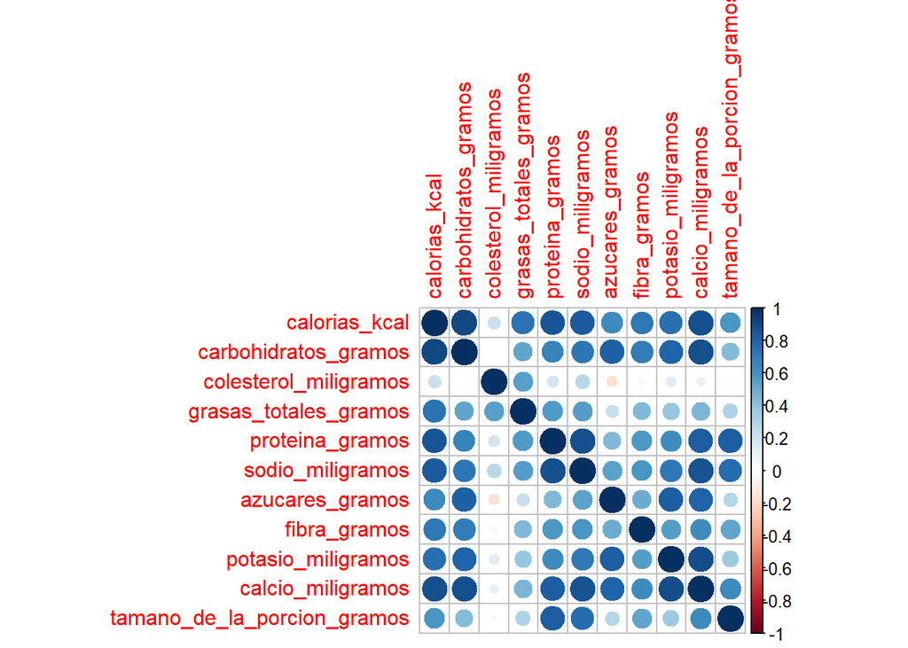

```r
# Una gráfica más

library(corrplot)
corrplot(cor(numericas))   # correlograma
```

Podemos ver que hay múltiples variables que tienen una relación de dependencia alta. La mayoría de estas colinealidades pertenecen cuando comparamos las calorías con las demás variables.

```r
library(car)
summary(influence.measures(modelo))
```

```
## Potentially influential observations of
##   lm(formula = calorias_kcal ~ carbohidratos_gramos + colesterol_miligramos +      grasas_totales_gramos + proteina_gramos + sodio_miligramos +      azucares_gramos + fibra_gramos + potasio_miligramos + calcio_miligramos +      tamano_de_la_porcion_gramos + producto, data = datos3) :
##
##     dfb.1_        dfb.crb_      dfb.cls_      dfb.gr__      dfb.prt_
## 2   -3.000000e-02  8.000000e-02  2.000000e-02 -5.000000e-02  8.000000e-02
## 3    0.000000e+00  0.000000e+00  0.000000e+00  0.000000e+00  0.000000e+00
## 5   -1.200000e-01  3.000000e-02 -1.200000e-01  1.100000e-01 -1.000000e-02
## 10   0.000000e+00  0.000000e+00  0.000000e+00  0.000000e+00  0.000000e+00
## 13   0.000000e+00  0.000000e+00  0.000000e+00  0.000000e+00  0.000000e+00
## 19   0.000000e+00  0.000000e+00  0.000000e+00  0.000000e+00  0.000000e+00
## 21   3.000000e-02 -9.000000e-02 -3.000000e-02  7.000000e-02 -1.000000e-01
## 24   0.000000e+00  0.000000e+00  0.000000e+00  0.000000e+00  0.000000e+00
## 31   0.000000e+00  0.000000e+00  0.000000e+00  0.000000e+00  0.000000e+00
## 39   0.000000e+00  0.000000e+00  0.000000e+00  0.000000e+00  0.000000e+00
## 40   0.000000e+00  0.000000e+00  0.000000e+00  0.000000e+00  0.000000e+00
```

[output cut: 393 more lines]

Todas estas son las observaciones que marca el programa, vamos a mostrarlas de una manera más visual.

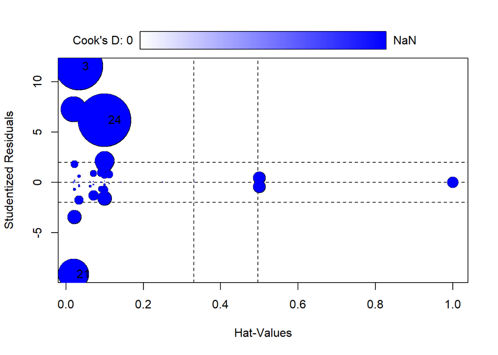

|  | StudRes | Hat | CookD |
| --- | --- | --- | --- |
| 3 | 11.528097 | 0.0333333 | 0.0761060 |
| 13 | NaN | 1.0000000 | NaN |
| 19 | NaN | 1.0000000 | NaN |
| 21 | -9.127011 | 0.0192308 | 0.0310449 |
| 24 | 6.185453 | 0.1000000 | 0.0930007 |

```r
influencePlot(modelo)
```

Podemos ver que hay algunas observaciones que presentan un peligro. Hay que tener más cuidado con las observaciones 3, 13, 19, 21 y 24.

### Propuesta de R

```r
step(object = modelo, direction = "both", trace = 1)  # stepwise mixto
```

```
## Start:  AIC=-16614.68
## calorias_kcal ~ carbohidratos_gramos + colesterol_miligramos +
##     grasas_totales_gramos + proteina_gramos + sodio_miligramos +
##     azucares_gramos + fibra_gramos + potasio_miligramos + calcio_miligramos +
##     tamano_de_la_porcion_gramos + producto
```

```
##
## Step:  AIC=-16563.84
## calorias_kcal ~ carbohidratos_gramos + colesterol_miligramos +
##     grasas_totales_gramos + proteina_gramos + sodio_miligramos +
##     azucares_gramos + fibra_gramos + potasio_miligramos + calcio_miligramos +
##     producto
```

```
##
## Call:
## lm(formula = calorias_kcal ~ carbohidratos_gramos + colesterol_miligramos +
##     grasas_totales_gramos + proteina_gramos + sodio_miligramos +
##     azucares_gramos + fibra_gramos + potasio_miligramos + calcio_miligramos +
##     producto, data = datos3)
##
## Coefficients:
##                      (Intercept)              carbohidratos_gramos
##                          8.79752                           4.18029
##            colesterol_miligramos             grasas_totales_gramos
##                          0.82239                           7.09589
##                  proteina_gramos                  sodio_miligramos
##                          4.25502                           0.06233
##                  azucares_gramos                      fibra_gramos
##                         -0.65034                          -4.44535
##               potasio_miligramos                 calcio_miligramos
##                         -0.11668                           0.06722
##    productocamarones_empanizados               productochilaquiles
##                         20.38415                          60.36612
##          productochile_en_nogada                  productocuernito
##                        -23.88349                         -10.67585
##                     productodona                  productoensalada
##                        -18.66241                         -85.03280
##                    productofruta     productohamburguesa_con_papas
##                         22.26152                        -220.00823
##                productohot_cakes            productohot_cakes_ihop
##                         -8.79752                          15.50941
##        productohuevo_con_chorizo           productohuevo_con_jamon
##                       -367.21566                        -313.14774
##      productolicuado_de_proteina      productolicuado_frutos_rojos
##                        -23.73333                           3.68400
##                productomandarina                   productomanzana
##                         11.12420                          11.72579
##            productomedia_gordita         productopalomitas_doritos
##                       -262.74909                         250.03354
##    productopan_tostado_con_huevo              productopanque_limon
##                       -404.54533                          22.26152
##      productopapas_a_la_francesa       productopechuga_cordon_blue
##                        -20.74416                        -268.42299
##                   productopicana                     productopizza
##                       -282.01146                         -51.53961
##                  productoplatano           productopollo_enchilado
##                        -15.67030                         -23.26797
## productorebanada_panque_arandano       productorebanada_red_velvet
##                       -586.18057                        -538.76564
## productorollitos_pollo_con_queso                   productoruffles
##                         -0.81214                          29.29459
##                   productosandia                  productosandwich
##                               NA                                NA
##                     productosope                      productouvas
##                               NA                                NA
##       productoyogurt_con_manzana           productoyogurt_con_uvas
##                               NA                                NA
```

De acuerdo a R, me recomienda un modelo que no toma en cuenta el tamaño de la porción. Sin embargo yo la considero una variable importante ya que como no consumo tantos alimentos envasados, debo cuidar más mis porciones cuando preparo y escojo mis alimentos.

# Fase 4. Implementación y comunicación

```r
levels(datos3$producto)
```

```
##  [1] "alitas"                   "camarones_empanizados"
##  [3] "chilaquiles"              "chile_en_nogada"
##  [5] "cuernito"                 "dona"
##  [7] "ensalada"                 "fruta"
##  [9] "hamburguesa_con_papas"    "hot_cakes"
## [11] "hot_cakes_ihop"           "huevo_con_chorizo"
## [13] "huevo_con_jamon"          "licuado_de_proteina"
## [15] "licuado_frutos_rojos"     "mandarina"
## [17] "manzana"                  "media_gordita"
## [19] "palomitas_doritos"        "pan_tostado_con_huevo"
## [21] "panque_limon"             "papas_a_la_francesa"
## [23] "pechuga_cordon_blue"      "picana"
## [25] "pizza"                    "platano"
## [27] "pollo_enchilado"          "rebanada_panque_arandano"
## [29] "rebanada_red_velvet"      "rollitos_pollo_con_queso"
## [31] "ruffles"                  "sandia"
## [33] "sandwich"                 "sope"
## [35] "uvas"                     "yogurt_con_manzana"
## [37] "yogurt_con_uvas"
```

## Pronóstico

En el siguiente paso asignaremos valores al azar de 10 alimentos para poder hacer la predicción de las calorías. Para hacer esto usaremos el modelo que hicimos anteriormente

```r
nuevos_datos <- data.frame(calorias_kcal = c(43, 100, 619, 350, 300, 350, 400, 1000,
                                             450,300),
                           carbohidratos_gramos = c(3,80,4,20,81,50,13,300, 60,100),
                           colesterol_miligramos = c(0,20,100,0,100,30,50,0,50,130),
                           grasas_totales_gramos = c(5,46,30,1,5,13,27,30,19,20),
                           proteina_gramos = c(0,35,10,1,30,25,30,1,40,7),
                           sodio_miligramos = c(10,900,400,1,200,100,250,700,350,133),
                           azucares_gramos = c(20,24,13,0,30,3,10,8,9,30),
                           fibra_gramos = c (1,2,3,8,1,6,7,2,4.5,6.7),
                           potasio_miligramos = c (589,0,100,100,425,124,351,426,123,215),
                           calcio_miligramos = c(0,815,100,50,150,545,234,0,55,315),
                           tamano_de_la_porcion_gramos = c(480, 250, 150, 100, 250, 200,
                           300,354,400,80),
                           producto = c("fruta", "ensalada",
                           "yogurt_con_manzana",
                           "manzana", "platano", "hot_cakes", "huevo_con_chorizo",
                           "palomitas_doritos", "alitas", "cuernito"))

class(nuevos_datos)
```

```
## [1] "data.frame"
```

```r
predicciones <- predict(modelo, nuevos_datos)
predicciones
```

```
##         1         2         3         4         5         6         7         8
##  154.2631 1048.6602   72.8392  105.4594  244.8418  314.4342 1599.7949 1474.7837
##         9        10
##  532.1531  185.1169
## attr(,"non-estim")
##  1  2  3  4  5  6  7  8  9 10
##  1  2  3  4  5  6  7  8  9 10
```

## Interpretación y comunicación de los pronósticos

### Primer pronóstico

Si comiera 480 gramos de fruta (casi medio kilo), con cantidades altas de potasio y muy poco de lo demás, entonces estaría consumiendo aproximadamente 154 calorías. Lo cual no está mal ya que las frutas no tienen mucho aporte calórico. Esto significa que la puedo seguir incluyendo en mi dieta.

### Segundo pronóstico

Si comiera 250 gramos de ensalada con 815 miligramos de calcio, 0 de potasio, 900 de sodio, 20 de colesterol, 80 gramos de carbohidratos, 46 de grasas totales, 35 de proteína, 24 de azúcares, y 2 de fibra; entonces estaría consumiendo alrededor de 1048 calorías. Esto es mucho para una persona de mi edad. Es por ello que de ahora en adelante cuidaré mis porciones de ensalada, no la comeré todos los días e intentaré que tengan menos carbohidratos y calorías ya que la razón por la que suben mucho es por ingredientes como los croutones, pasta y el pollo sazonado.

### Cuarto pronóstico

Si comiera 100 gramos de manzanas,50 miligramos de calcio, 100 de potasio, 1 de soio y 0 de colesterol entonces estaría consumiendo 105 calorías aproximadamente. Lo bueno es que cuando como manzanas solo me como 1 y solo la uso como colación cuando tengo mucha hambre. Esto significa que puedo seguir consumiéndola.

### Quinto pronóstico

Si comiera 250 gramos de plátanos, 150 miligramos de calcio, 425 de potasio, 200 de sodio, 100 de colesterol, 81 gramos de carbohidratos, 5 de grasas, 30 de proteína, 30 de azúcares y 1 de fibra, entonces voy a estar consumiendo alrededor de 244 calorías. Puede que no sea tanto, sin embrago, es bien sabido que los plátanos tienen mucha azúcar aunque sea de la natural. Es por ello que debo procurar consumirlos de vez en cuando como colación

### Noveno pronóstico

Si comiera 400 gramos de alitas, 55 miligramos de calcio, 123 de potasio, 350 de sodio, 50 de colesterol, 4.5 gramos de fibra, 9 de azúcares, 40 de proteína, 19 de grasas y 60 de carbohidratos, entonces estaría consumiendo alrededor de 532 calorías. Lo cual no está tan mal considerando el tamaño de la porción. Sin embrago, al momento de trabajar en este proyecto, no consideré el aderezo ni las salsas ya que comí alitas de distintos sabores, así que al momento de encontrar los datos usé los de las alitas con salsa picante. También debo tener un consumo moderado de las alitas, ya que a pesar de ser proteína. la forma en la que se preparan no es muy sana. También debo procurar no ponerles aderezo, y si lo hago ponerles poco.

### Décimo pronóstico

Si comiera 80 gramos de cuernitos, 315 miligramos de calcio, 215 de potasio, 133 de sodio, 130 de colesterol, 100 gramos de carbohidratos, 20 de grasas, 7 de proteína, 30 de azúcar y 6.7 de fibra, entonces estaría consumiendo alrededor de 185 calorías. La cantidad de calorías no es tan grande, lo cual significa que podría seguir siendo una buena opción de alimento para mis desayunos. Solo que debo tener cuidado con este tipo de alimentos ya que como es pan (aunque tenga lechuga, jamón y queso) es muy probable que cause que aumente de peso. Es por ello que intentaré regular más mi consumo de cuernitos.

# Preguntas finales

## ¿Qué ajustes se tuvieron que hacer a los datos (agregar datos, integrar datos, modificar datos (remover o eliminar información)?

Los ajustes que se tuvieron que hacer a los datos fueron imputación (para no tener datos faltantes), escoger variables y juntarlas en un nuevo conjunto de datos, limpiarlos y convertir la variable producto en factor

## ¿Cuántos modelos se intentaron para obtener el modelo final?

Se intentaron 5 modelos distintos dos de ellos eran con los datos tranformados y eran regresiones lineales, otros dos fueron regresiones lineales con los datos sin transformar, el último fue el de regresión múltiple, con el que decidimos quedarnos ya que todas las variables tenían un valor p menor a 0.05. También le pedimos a r que mostrara el mejor modelo que pudiera encontrar, sin embargo, este no incluía el tamaño de la porción, y yo considero que esta variable es muy importante ya que, como dicen, todo debe ser con medida y todo en exceso es malo, así que esta variable puede ayudarme a demostrarlo.

## ¿Cuáles variables explican el comportamiento del contenido calórico de tus alimentos?

Las variables que explican eel comportamiento del contenido calórico de mis alimentos son el producto, carbohidratos, colesterol, grasas, proteína, sodio, azúcares, fibra, potasio, calcio y tamaño de porción

## ¿Encontraste diferencias entre los grupos calóricos? Si es así, explica.

Sí encontré diferencias entre los grupos calóricos. Confirmé que carios de los alimentos que tienen más calorías son los que tienen más carbohidratos también. Algunos de los alimentos que estaban en las calorías bajas eran frutas

## ¿Qué conclusiones brindó esta fase de modelación para aceptar o rechazar la hipótesis inicial? Recuerda que esta es: Si consumo cierta cantidad calórica, ¿puedo tener cambios en mi masa corporal (peso) en un determinado tiempo?

Esta fase de la modelación me ayudó a llegar a la conclusión de que sí puedo tener cambios en mi masa corporal en un determinado tiempo si consumo cierta cantidad calórica ya que al finalizar este proyecto me dí cuenta de que perdí alrededor de dos kilos desde que empecé. Sin embargo, soy una persona que realiza mucha actividad física, por lo que podría haber bajado más. Me di cuenta de que hay varias cosas que todavía puedo mejorar de mi dieta.

# Conclusiones